# Algorithm Class 22 - Practice 13

Map/Set/Hash

June/23/2019

# 1 Set

A collection that **cannot contain duplicate elements**.

The Java platform contains three general-purpose `Set` implementation: **`HashSet`**, `TreeSet`, and `LinkedHashSet`.

- **`HashSet`**: which stores its elements in a **hashtable**, is the best-performing implementation; however it makes no guarantees concerning the order of iteration.
- **`TreeSet`**: which stores its elements in a red-black tree (balanced binary search tree), **orders** its elements based on their values.
- **`LinkedHashSet`**: it is a HashSet and also it is a LinkedList, it maintains the order when each of the elements is inserted into the HashSet.
  - Hash table and linked list implementation of the `Set` interface, with predictable iteration order. This implementation differs from HashSet in that it maintains a doubly-linked link running through all of its entries. This linked list defines the iteration ordering, which is the order in which elements were inserted into the set (insertion-order).

# 2 Map

A collection that maps keys to values. A Map cannot contain duplicate keys; each key can map to one value.

- A collection that stores `<key, value>` pairs, such that no duplicate keys are allowed.

The Java platform contains three general-purpose `Map` implementations: **`HashMap`**, `TreeMap`, and `LinkedHashMap`.

# 3 HashMap

## 3.1 Common API

http://docs.oracle.com/javase/8/docs/api/java/util/HashMap.html

- `V put(K key, V value)`, `V` is the old value of that key
- `V get(Object key)`
  - The reason why `get()`, etc. is not generic because the key of the entry you are retrieving does not have to be the same type as the object that you pass in to `get()`; the specification of the method only requires that they be equal. This follows from how the `equals()` method takes in an Object as parameter, not just the same type as the object.
  - Although it may be commonly true that many classes have `equals()` defined so that its objects can only be equal to objects of its own class, there are many places in Java where this is not the case. For example, the specification for `List.equals()` says that two List objects are equal if they are both Lists and have the same contents, even if they are different implementations of List.
- `V remove(K key)`
- `boolean containsKey(Object key)`
- `Set<Map.Entry<K, V>> entrySet()`: get the set **view** of all the entries in the hashmap
- `Set<K> keySet()`: get the set **view** of all the keys in the hashmap
- `Collection<V> values()`: get the collection **view** of all the values in the hashmap
- `boolean containsValue(V value)`: O($n$)
- `void clear()`
- `int size()`
- `boolean isEmpty()`

## 3.2 Time Complexity

| Operation | Average | Worst |
| --- | --- | --- |
| search: `boolean containsKey(Object key)`, `V get(K key)` | O($1$) | O($n$) |
| insert/update: `V put(K key, V value)` | O($1$) | O($n$) |
| delete: `V remove(K key)` | O($1$) | O($n$) |

```java
public class HashUsing {
  public HashUsing() {

  }

  public static void main(String[] args) {
    Map<String, Integer> employerNumbers = new HashMap<>();
    employerNumbers.put("yahoo", 1);
    System.out.println(employerNumbers);  // {yahoo : 1}

    employerNumbers.put("google", 2);
    System.out.println(employerNumbers);  // {yahoo : 1, google : 2}
    Integer yc = employerNumbers.get("yahoo");  // yc = 1

    // yc is the previous value for key "yahoo"
    yc = employerNumbers.put("yahoo", 5);
    // {yahoo : 5, google : 2}
    System.out.println(yc); // yc = 1

    yc = employerNumbers.get("yahoo");  // yc = 5
    // fc = null (if the key is not in the map, get(key) will return null)
    Integer fc = employerNumbers.get("facebook");

    // fe = false;
    boolean fe = employerNumbers.containsKey("facebook");

    fc = employerNumbers.remove("facebook");
    System.out.println(fc); // fc = null

    // {yahoo : 5, google : 2}
    Integer gc = employerNumbers.remove("google");

    System.out.println(gc); // 2
    System.out.println(employerNumbers);  // {yahoo : 5}
  }
}
```

## 3.3 HashMap v.s. Hashtable

Similar to ArrayList v.s. Vector

Vector, Hashtable exist from Java 1.0.

ArrayList, HashMap introduced from Java 5.

1. Hashtable does not allow null key, but HashMap allows one null key.
2. Vector and Hashtable operations are synchronized, introduce a lot of performance penalty

**We do not use Hashtable anymore.**

## 3.4 A HashMap Implementation - I

- A table of **buckets** (an array of buckets), using the array index to denote each bucket.
- For each `<key, value>`, it goes to one of the buckets, the bucket index is determined by a **hash function** applied on **key** and the size of array.

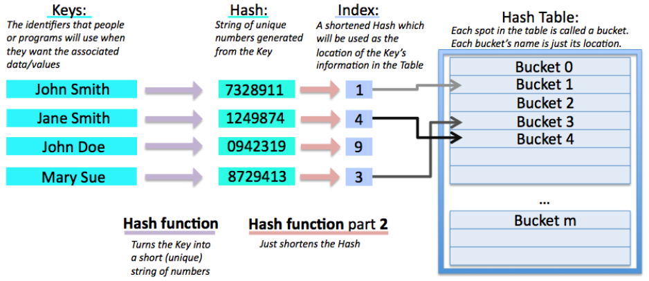

- **Collision Control**
  - Collision: two keys mapped to the same bucket
  - **Separate Chaining** (Close Addressing): the element of each of the buckets is actually a single linked list.
  - **Open Addressing**: put the key-value pair into the “next” available bucket.
    - How to define next? Linear/quadratic/exponential probing, hash again.
    - Challenge: handling removed keys in the map.
    - Not used by Java, but by some real life systems.
  - If different Keys are determined to sue the same bucket, they will be chained in the list.

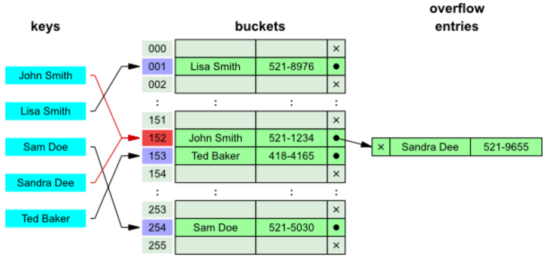

- What are the elements in the buckets? Singly Linked List, each node contains one `<key, value>` pair

```java
class Entry<K, V> {
  K key;
  V value;
  Entry<K, V> next;
}
```

http://docs.oracle.com/javase/8/docs/api/java/util/Map.Entry.html

## 3.5 HashMap Operations

- `put(key, value)`
  1. `int hash = hash(key)`: hash
  2. `int index = hash % table_size`: index
  3. search for the list resides in the bucket to see if the key already exists
     1. if not find the same key already existed, add a new Entry node to the list
     2. if find an Entry with the same key, update the value of that Entry
- `get(key)`
  1. `int hash = hash(key)`: hash
  2. `int index = hash % table_size`: index
  3. search for the list resides in the bucket to see if the key already exists

**HashMap can only has one null key, it is always mapped to bucket 0.**

## 3.6 HashMap Implementation

Get into a little details about HashMap Implementation:

- array of entries
- each entry is actually a single linked list (handle collision)
  - contains the `<key, value>` pair

1. Define the class for each entry:

```java
class Entry<K, V> {
  private final K key;
  private V value;
  Entry<K, V> next;
  Entry(K key, V value) {
    this.key = key;
    this.value = value;
  }

  public K getKey() {
    return key;
  }

  public V getValue() {
    return value;
  }

  public void setValue(V value) {
    this.value = value;
  }
}
```

2. Maintain an array of entries:

```java
Entry<K, V>[] array;
```

- To get(K key), put(K key, V value), remove(K key), we follow the steps:
  1. hash(key) to hash#.
  2. hash# to entry index in the array.
  3. from the corresponding singly linked list, iterate all of the nodes to find if the same key exists.

3. hash(key) to get the hash# (hash value)

```java
private int hash(K key) {
  // return the hash# of the key
  if (key == null) {
    return 0;
  }
  int hashNumber = key.hashCode();
  // post processing to make the hashNumber non-negative
}
```

4. From the hash#, mapped to the entry index.

```java
int getIndex(int hashNumber) {
  // return the corresponding index of array
  return hashNumber % array.length;
}
```

5. When iterate the corresponding entry for the given key, which is actually a singly linked list, we need compare each of the entry in the list, if **the key is the same** as the key we want.

```java
Entry<K, V> curr = array[index];
while (curr != null) {
  K currKey = curr.getKey();
  if (currKey is the same as given key) {
    // ... helper function: isEqual()
  }
  curr = curr.next;
}
```

Two Questions Here:

1. “HashMap get(key), put(key, value), remove(key) is O($1$)”, is it always true? What is the major factor affecting the time complexity?
   1. hash(key) -> key.hashCode()
   2. Load factor (# of key-value pairs / # of buckets)
2. When we need to know if a key is already in the HashMap, we need to find its bucket, then traverse the linked list in that bucket to see if there is a same key already existed. How do we define “the same key”?
   1. key.equals(anotherKey)

Very Important: HashMap use

- `key.hashCode()`: to determine the entry index for the key
- `key.equals()`: to determine whether two keys are the same keys

## 3.7 `==`, `equals()`, `hashCode()`

1. `==`

- determine if two primitive types have the same value.
- **determine if two references are pointed to the same object.**

2. `equals()`, `hashCode()`

- defined in `Object` class, Object is the root class for any Java class
- any Java class implicitly extends Object class, so if in the subclass these two methods are not overridden, it inherits what if defines in Object class.
- the default implementation of equals() is check if the two references are pointed to the same object `==`.
- the default implementation of hashCode() returns a “unique hash value” for the object based on its memory address.

```java
class Object {
  public boolean equals(Object obj) {
    return this == obj;
  }
  public int hashCode() {
    // Here it returns the object's hash value based on its memory address. It is unique for each object.
  }
  public String toString() {
    // ...
  }
}
```

- sometimes we do not want to compare the reference, we want to compare the **object’s content**.

**Example: (from an existing class)**

```java
// s1 and s2 are different String objects
String s1 = "abc";
String s2 = new String("abc");

// this will return false, "==" always compare if they are the same object
s1 == s2;

// this will return true, "equals()" for String class actually checks the value
s1.equals(s2);
```

Why `s1.equals(s2) == true`?

- In `String` class, the `equals()` method is overridden:

```java
class String {
  char[] array;
  int offset;
  int length;

  @Override
  public boolean equals(Object obj) {
    if (obj == this) {
      return true;
    }
    if (!(obj instanceof String)) {
      return false;
    }
    String another = (String) obj;
    // check each of the characters of the two String object if they are the same
    if (this.length != another.length) {
      return false;
    }
    for (int i = 0; i < this.length; i++) {
      if (this.array[this.offset + i] != another.array[another.offset + i]) {
        return false;
      }
    }
    // return true if they match
    return true;
  }
}
```

**Example (out own class):**

Class has to override `equals()`, `hashCode()` of you want to have a different meaning than comparing the references.

```java
// representing a (x, y) coordinate on the grid
class Coordinate {
  public int x;
  public int y;
  public Coordinate(int x, int y) {
    this.x = x;
    this.y = y;
  }
}
```

If in your own class, the `equals()` and `hashCode()` methods have not been overridden, it will inherit the methods from `Object` class.

```java
Coordinate one = new Coordinate(0, 0);
Coordinate another = new Coordinate(0, 0);

one == another; // false
System.out.println(one.equals(another));  // false
```

```java
class Coordinate {
  public int x;
  public int y;
  public Coordinate(int x, int y) {
    this.x = x;
    this.y = y;
  }
  @Override
  public boolean equals(Object obj) {
    if (obj == this) {
      return true;
    }
    if (!(obj instanceof Coordinate)) {
      return false;
    }
    Coordinate another = (Coordinate) obj;
    return this.x == another.x && this.y == another.y;
  }
}

Coordinate one = new Coordinate(0, 0);
Coordinate another = new Coordinate(0, 0);

one == another; // false
System.out.println(one.equals(another));  // true
```

**What about `hashCode()`?**

- `hash(key)` to get the hash#

```java
int hash(K key) {
  // return the hash# of the key
  if (key == null) {
    return 0;
  }
  int hashNumber = key.hashCode();
  // post processing to make the hashNumber non-negative
}
```

- From the hash#, mapped to the bucket index

```java
int getIndex(int hashNumber) {
  // return the corresponding index of array
  return hashNumber % array.length;
}
```

Remember, in Hashmap, `key.hashCode()` method determines which entry the key will go to, we need to guarantee the same keys always go to the same entry.

```
("yahoo", 2) -> index = 1
put ("yahoo", 5) -> "yahoo".hashCode() -> index = 1
```

In Java, there is a contract between `equals()` and `hashCode()`, the developers need to maintain:

- If `one.equals(two)`, it is a must that `one.hashCode() == two.hashCode()`
- If `one.hashCode() == two.hashCode()`, it is not necessary `one.equals(two)`

When you want to override `equals()`, please definitely override `hashCode()` as well

Only by doing this, you can make sure the HashMap will still work for the key type.

- What if hashCode returns address?
  - No
- What if hashCode returns 0?
  - OK, but not good

**`hashCode()` is VERY important!**

1. The performance of HashMap solely depends on how good the `hashCode()` is.
   - Bad `hashCode()` can lead to linear time complexity in extreme case. For example, if all the keys has the same hash number returned by `.hashCode()`.
2. Easy, fast, efficient.
3. Minimize collision, as evenly distributed as possible.

## 3.8 Demo of `equals()` and `hashCode()`

### 3.8.1 Override Neither `equals()` Nor `hashCode()`

```java
public class Test {
  public static void main(String[] args) {
    Set<Coordinate> set = new HashSet<>();
    set.add(new Coordinate(1, 3));
    set.add(new Coordinate(1, 3));
    System.out.println(set);
  }
}

class Coordinate {
  int x;
  int y;
  public Coordinate(int a, int b) {
    x = a;
    y = b;
  }
  @Override
  public String toString() {
    return "(" + x + "," + y + ")";
  }
}
```

```
[(1,3), (1,3)]
```

### 3.8.2 Override Only `equals()`

```java
public class Test {
  public static void main(String[] args) {
    Set<Coordinate> set = new HashSet<>();
    set.add(new Coordinate(1, 3));
    set.add(new Coordinate(1, 3));
    System.out.println(set);
  }
}

class Coordinate {
  int x;
  int y;
  public Coordinate(int a, int b) {
    x = a;
    y = b;
  }
  @Override
  public String toString() {
    return "(" + x + "," + y + ")";
  }
  @Override
  public boolean equals(Object other) {
    if (!(other instanceof Coordinate)) {
      return false;
    }
    Coordinate o = (Coordinate) other;
    return x == o.x && y == o.y;
  }
}
```

```
[(1,3), (1,3)]
```

### 3.8.3 Override Both `equals()` And `hashCode()`

```java
public class Test {
  public static void main(String[] args) {
    Set<Coordinate> set = new HashSet<>();
    set.add(new Coordinate(1, 3));
    set.add(new Coordinate(1, 3));
    System.out.println(set);
  }
}

class Coordinate {
  int x;
  int y;
  public Coordinate(int a, int b) {
    x = a;
    y = b;
  }
  @Override
  public String toString() {
    return "(" + x + "," + y + ")";
  }
  @Override
  public boolean equals(Object other) {
    if (!(other instanceof Coordinate)) {
      return false;
    }
    Coordinate o = (Coordinate) other;
    return x == o.x && y == o.y;
  }
  @Override
  public int hashCode() {
    return 31 * x + y;  // 31是個不大不小的質數
  }
}
```

```
[(1,3)]
```

## 3.9 Common `hashCode()` Implementation

```java
class Combo {
  int a;
  B b;
  C c;
  public Combo(int a, B b, C c) {
    this.a = a;
    this.b = b;
    this.c = c;
  }

  @Override
  public int hashCode() {
    return a * 31 * 31 + b.hashCode() * 31 + c.hashCode();
  }
}
```

## 3.10 Rehashing, Load Factor

- Rehashing
  - is needed when there are too many `<key, value>` pairs maintained in the hashmap (too many collisions)
  - expand the array to a larger one and move all the `<key, value>` pairs to the new array (in HashMap by default, the array size is **doubled** each time)
  - Rehashing is global wise - meaning all the `<key, value>` pairs need to participate
- Load factor
  - to control when rehashing is needed, maintain the ratio of number of `<key, value>` pairs / number of buckets
  - default 0.75
  - when the ratio exceeds the limit, rehashing will happen

# 4 HashSet

It is backed up by a HashMap instance. Only care about the Key here.

## 4.1 Common API

http://docs.oracle.com/javase/7/docs/api/java/util/HashSet.html

- `boolean add(E e)`
- `boolean remove(Object o)`
- `boolean contains(Object o)`
- `void clear()`
- `int size()`
- `boolean isEmpty()`

```java
class HashSet<K> {
  private HashMap<K, Object> map;

  // special object used for all the existing keys
  private static final Object PRESENT = new Object();

  public HashSet() {
    map = new HashMap<K, Object>();
  }
  public boolean contains(K key) {
    return map.containsKey(key);
  }
  public boolean add(K key) {
    return map.put(key, PRESENT) == null;
  }
  // more methods...
}
```

# 5 Practice Of HashMap/HashSet With `equals()` and `hashCode()`

## 5.1 String Permutation

No duplication

```java
String s3 = "abcde";
char[] s3_1 = s3.toCharArray();
System.out.println(new String(s3_1, 0, 2));
System.out.println(new String(s3_1, 1, 2));
System.out.println(new String(s3_1, 2, 3));
System.out.println(new String(s3_1, 3, 4));
```

```
ab
bc
cde
Exception in thread "main" java.lang.StringIndexOutOfBoundsException: String index out of range: 7
      at java.lang.String.<init>(String.java:205)
      at laioffer.HashUsing.main(HashUsing,java:64)
```

`String(char[] value, int offset, int count)`: Allocates a new String that contains characters from a subarray of the character array argument.

```java
public class Solution {
  public List<String> permutations(String set) {
    List<String> result = new ArrayList<String>();
    if (set == null) {
      return result;
    }
    chat[] arrayset = set.toCharArray();
    helper(arrayset, 0, result);
    return result;
  }
  public void helper(char[] set, int index, List<String> result) {
    if (index == set.length) {
      result.add(new String(set));
      return;
    }
    for (int i = index; i < set.length; i++) {
      swap(set, index, i);
      helper(set, index + 1, result);
      swap(set, index, i);
    }
  }
  public void swap(char[] set, int index, int i) {
    char temp = set[index];
    set[index] = set[i];
    set[i] = temp;
  }
}
```